```python
name = "Annabelle Allen"
Date = "12/7/2022"
```

# Data Set and Project Summary

I am using the same data file/csv that I got from kaggle for the first project for this assignment. The change that I will be making between this assignment and the previous one, is the factor from the data that I will be analyzing. Previously we looked at the happiness score in relation to the facors. This time I will be analyzing the relationship of the cpi score to happiness score, and gdp to see if it has a significant relationship.

The cpi score is a Corruption Perception Index, which is a score from Transparency which is an organization that is dedicated to eliminating corruption within governments globally. They created the Corruption perception index to measure government corruptiona nd transparency, it is caluclated from surveys that are completed by residents of said country. It lies on a scale of 0-100, 100 meaning no corruption, 0 being the most corrupted.

The regression models I will be using for this project are correlations and anova regression models. I will create correlation matrices for the different factors that I am comparing(cpi and happiness and cpi and gdp). I will be using a pearson correlation to compare them. The pearson correlation is a ratio that compares the covariability of X and Y, in this case, either cpi and happiness or cpi and gdp with with the variability of X and Y separately. However, I also included correlation matrices from the other two types, the kendall and spearman correlation which are are used to determine correlation with in ranks. These I decided to not use for calculating my correlation coefficients because we are not looking at how the gdp or happiness is ranked in the individual countries compared to the cpi score. After this I used an anova regression model to create a deeper analysis. this is explained in that section.

# Importing Libraries

this also looks at the data originally

```python
import numpy as np
import pandas as pd
import seaborn as sb
import scipy.stats
import matplotlib.pyplot as plt
from sklearn import datasets, linear_model
from sklearn.metrics import mean_squared_error, r2_score
import statsmodels.formula.api as smf
import statsmodels.api as sm
```

```python
happiness = pd.read_csv(r'~/Downloads/WorldHappiness_Corruption_2015_2020.csv')
happiness.head()
```

|  | Country | happiness_score | gdp_per_capita | family | health | freedom | generosity | government_trust | dystopia_residual | continent | Year | social_support | cpi_score |
| --- | --- | --- | --- | --- | --- | --- | --- | --- | --- | --- | --- | --- | --- |
| 0 | Norway | 7.537 | 1.616463 | 1.533524 | 0.796667 | 0.635423 | 0.362012 | 0.315964 | 2.277027 | Europe | 2015 | 0.0 | 88 |
| 1 | Denmark | 7.522 | 1.482383 | 1.551122 | 0.792566 | 0.626007 | 0.355280 | 0.400770 | 2.313707 | Europe | 2015 | 0.0 | 91 |
| 2 | Iceland | 7.504 | 1.480633 | 1.610574 | 0.833552 | 0.627163 | 0.475540 | 0.153527 | 2.322715 | Europe | 2015 | 0.0 | 79 |
| 3 | Switzerland | 7.494 | 1.564980 | 1.516912 | 0.858131 | 0.620071 | 0.290549 | 0.367007 | 2.276716 | Europe | 2015 | 0.0 | 86 |
| 4 | Finland | 7.469 | 1.443572 | 1.540247 | 0.809158 | 0.617951 | 0.245483 | 0.382612 | 2.430182 | Europe | 2015 | 0.0 | 90 |

```python
happiness.corr(method = 'pearson')
```

|  | happiness_score | gdp_per_capita | family | health | freedom | generosity | government_trust | dystopia_residual | Year | social_support | cpi_score |
| --- | --- | --- | --- | --- | --- | --- | --- | --- | --- | --- | --- |
| happiness_score | 1.000000 | 0.793267 | 0.154946 | 0.753534 | 0.544284 | 0.155419 | 0.455477 | 0.174161 | 0.023495 | 0.192633 | 0.693001 |
| gdp_per_capita | 0.793267 | 1.000000 | 0.218191 | 0.774980 | 0.340260 | -0.018355 | 0.359068 | 0.042710 | -0.035782 | 0.111701 | 0.704483 |
| family | 0.154946 | 0.218191 | 1.000000 | -0.054683 | 0.013833 | 0.245437 | 0.114767 | 0.600243 | -0.588630 | -0.869885 | 0.132031 |
| health | 0.753534 | 0.774980 | -0.054683 | 1.000000 | 0.381869 | -0.028882 | 0.312741 | -0.073157 | 0.070172 | 0.347438 | 0.644478 |
| freedom | 0.544284 | 0.340260 | 0.013833 | 0.381869 | 1.000000 | 0.306240 | 0.473980 | -0.015270 | 0.058195 | 0.208709 | 0.482923 |
| generosity | 0.155419 | -0.018355 | 0.245437 | -0.028882 | 0.306240 | 1.000000 | 0.280039 | 0.147750 | -0.109797 | -0.215131 | 0.165972 |
| government_trust | 0.455477 | 0.359068 | 0.114767 | 0.312741 | 0.473980 | 0.280039 | 1.000000 | 0.098366 | 0.021781 | -0.008136 | 0.620089 |
| dystopia_residual | 0.174161 | 0.042710 | 0.600243 | -0.073157 | -0.015270 | 0.147750 | 0.098366 | 1.000000 | 0.057519 | -0.654570 | 0.032630 |
| Year | 0.023495 | -0.035782 | -0.588630 | 0.070172 | 0.058195 | -0.109797 | 0.021781 | 0.057519 | 1.000000 | 0.448616 | -0.001460 |
| social_support | 0.192633 | 0.111701 | -0.869885 | 0.347438 | 0.208709 | -0.215131 | -0.008136 | -0.654570 | 0.448616 | 1.000000 | 0.109077 |
| cpi_score | 0.693001 | 0.704483 | 0.132031 | 0.644478 | 0.482923 | 0.165972 | 0.620089 | 0.032630 | -0.001460 | 0.109077 | 1.000000 |

# data exploration

```python
happiness.isnull().sum()
```

```
Country              0
happiness_score      0
gdp_per_capita       0
family               0
health               0
freedom              0
generosity           0
government_trust     0
dystopia_residual    0
continent            0
Year                 0
social_support       0
cpi_score            0
dtype: int64
```

```python
happiness.head()
```

|  | Country | happiness_score | gdp_per_capita | family | health | freedom | generosity | government_trust | dystopia_residual | continent | Year | social_support | cpi_score |
| --- | --- | --- | --- | --- | --- | --- | --- | --- | --- | --- | --- | --- | --- |
| 0 | Norway | 7.537 | 1.616463 | 1.533524 | 0.796667 | 0.635423 | 0.362012 | 0.315964 | 2.277027 | Europe | 2015 | 0.0 | 88 |
| 1 | Denmark | 7.522 | 1.482383 | 1.551122 | 0.792566 | 0.626007 | 0.355280 | 0.400770 | 2.313707 | Europe | 2015 | 0.0 | 91 |
| 2 | Iceland | 7.504 | 1.480633 | 1.610574 | 0.833552 | 0.627163 | 0.475540 | 0.153527 | 2.322715 | Europe | 2015 | 0.0 | 79 |
| 3 | Switzerland | 7.494 | 1.564980 | 1.516912 | 0.858131 | 0.620071 | 0.290549 | 0.367007 | 2.276716 | Europe | 2015 | 0.0 | 86 |
| 4 | Finland | 7.469 | 1.443572 | 1.540247 | 0.809158 | 0.617951 | 0.245483 | 0.382612 | 2.430182 | Europe | 2015 | 0.0 | 90 |

```python
happiness.tail()
```

|  | Country | happiness_score | gdp_per_capita | family | health | freedom | generosity | government_trust | dystopia_residual | continent | Year | social_support | cpi_score |
| --- | --- | --- | --- | --- | --- | --- | --- | --- | --- | --- | --- | --- | --- |
| 787 | Botswana | 3.4789 | 0.997549 | 0.0 | 0.494102 | 0.509089 | 0.033407 | 0.101786 | 0.257241 | Africa | 2020 | 1.085695 | 60 |
| 788 | Tanzania | 3.4762 | 0.457163 | 0.0 | 0.442678 | 0.509343 | 0.271541 | 0.203881 | 0.718963 | Africa | 2020 | 0.872675 | 38 |
| 789 | Rwanda | 3.3123 | 0.343243 | 0.0 | 0.572383 | 0.604088 | 0.235705 | 0.485542 | 0.548445 | Africa | 2020 | 0.522876 | 54 |
| 790 | Zimbabwe | 3.2992 | 0.425564 | 0.0 | 0.375038 | 0.377405 | 0.151349 | 0.080929 | 0.841031 | Africa | 2020 | 1.047835 | 24 |
| 791 | Afghanistan | 2.5669 | 0.300706 | 0.0 | 0.266052 | 0.000000 | 0.135235 | 0.001226 | 1.507236 | Asia | 2020 | 0.356434 | 19 |

```python
happiness.info()
```

```
<class 'pandas.core.frame.DataFrame'>
RangeIndex: 792 entries, 0 to 791
Data columns (total 14 columns):
 #   Column             Non-Null Count  Dtype
---  ------             --------------  -----
 0   Country            792 non-null    object
 1   happiness_score    792 non-null    float64
 2   gdp_per_capita     792 non-null    float64
 3   family             792 non-null    float64
 4   health             792 non-null    float64
 5   freedom            792 non-null    float64
 6   generosity         792 non-null    float64
 7   government_trust   792 non-null    float64
 8   dystopia_residual  792 non-null    float64
 9   continent          792 non-null    object
 10  Year               792 non-null    int64
 11  social_support     792 non-null    float64
 12  cpi_score          792 non-null    int64
 13  cpi_avg            0 non-null      float64
dtypes: float64(10), int64(2), object(2)
memory usage: 86.8+ KB
```

```python
happiness.describe()
```

|  | happiness_score | gdp_per_capita | family | health | freedom | generosity | government_trust | dystopia_residual | Year | social_support | cpi_score | cpi_avg |
| --- | --- | --- | --- | --- | --- | --- | --- | --- | --- | --- | --- | --- |
| count | 792.000000 | 792.000000 | 792.000000 | 792.000000 | 792.000000 | 792.000000 | 792.000000 | 792.000000 | 792.000000 | 792.000000 | 792.000000 | 0.0 |
| mean | 5.473310 | 0.929217 | 0.504998 | 0.648691 | 0.427016 | 0.212440 | 0.125720 | 1.379277 | 2017.500000 | 0.609302 | 44.327020 | NaN |
| std | 1.124726 | 0.385774 | 0.552736 | 0.232261 | 0.148003 | 0.121660 | 0.109032 | 1.075276 | 1.708904 | 0.640754 | 19.508833 | NaN |
| min | 2.566900 | 0.000000 | 0.000000 | 0.000000 | 0.000000 | 0.000000 | 0.000000 | 0.000000 | 2015.000000 | 0.000000 | 11.000000 | NaN |
| 25% | 4.590750 | 0.644242 | 0.000000 | 0.510070 | 0.325433 | 0.125784 | 0.052862 | 0.000000 | 2016.000000 | 0.000000 | 30.000000 | NaN |
| 50% | 5.485500 | 0.994544 | 0.000000 | 0.685397 | 0.439621 | 0.197000 | 0.089000 | 1.731948 | 2017.500000 | 0.176214 | 38.000000 | NaN |
| 75% | 6.300500 | 1.228677 | 1.040410 | 0.815641 | 0.546280 | 0.273250 | 0.154250 | 2.236894 | 2019.000000 | 1.268250 | 57.000000 | NaN |
| max | 7.808700 | 2.096000 | 1.610574 | 1.141000 | 0.724000 | 0.838075 | 0.551910 | 3.602140 | 2020.000000 | 1.644000 | 91.000000 | NaN |

```python
avgCountry = happiness.pivot_table(index="Country",columns="Year",values="cpi_score")
avgCountry
```

| Year Country | 2015 | 2016 | 2017 | 2018 | 2019 | 2020 |
| --- | --- | --- | --- | --- | --- | --- |
| Afghanistan | 11 | 15 | 15 | 16 | 16 | 19 |
| Albania | 36 | 39 | 38 | 36 | 35 | 36 |
| Algeria | 36 | 34 | 33 | 35 | 35 | 36 |
| Argentina | 32 | 36 | 39 | 40 | 45 | 42 |
| Armenia | 35 | 33 | 35 | 35 | 42 | 49 |
| ... | ... | ... | ... | ... | ... | ... |
| Venezuela | 17 | 17 | 18 | 18 | 16 | 15 |
| Vietnam | 31 | 33 | 35 | 33 | 37 | 36 |
| Yemen | 18 | 14 | 16 | 14 | 15 | 15 |
| Zambia | 38 | 38 | 37 | 35 | 34 | 33 |
| Zimbabwe | 21 | 22 | 22 | 22 | 24 | 24 |

132 rows × 6 columns

```python
numeric_cols = ['gdp_per_capita', 'family', 'health','freedom', 'generosity', 'government_trust',
                'dystopia_residual', 'social_support', 'cpi_score']
categorical_cols = ['Country','continent', 'Year']
```

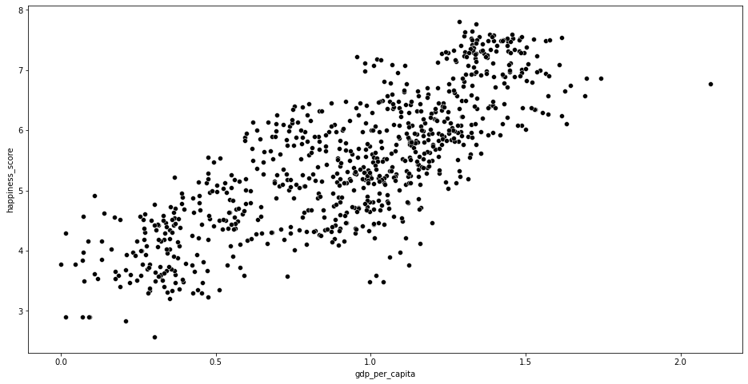

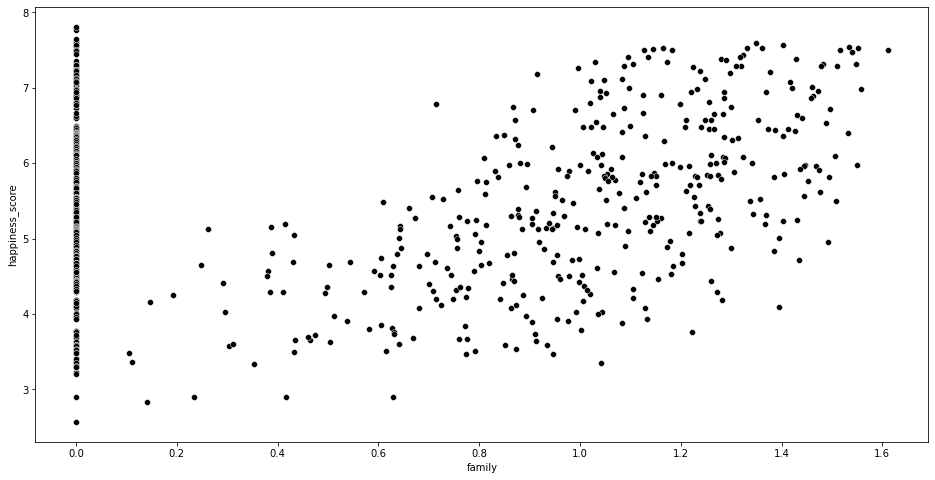

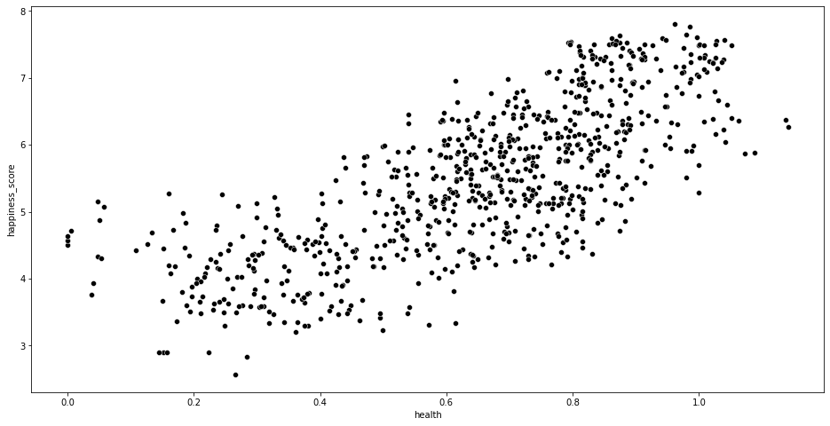

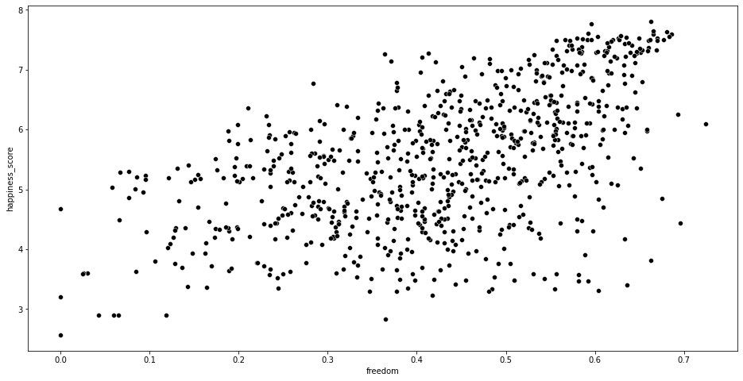

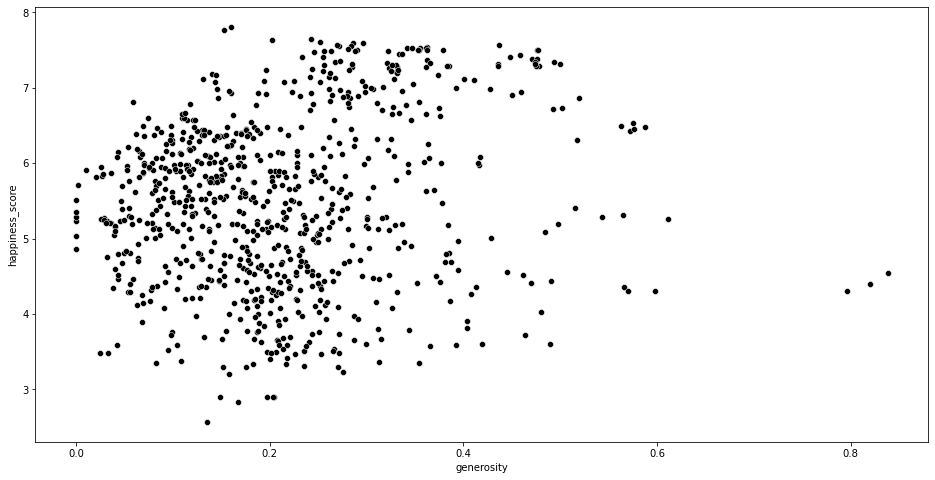

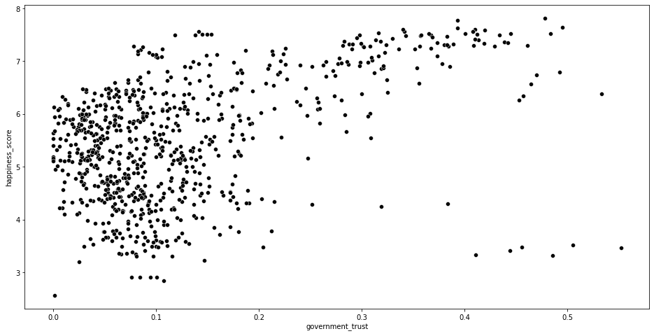

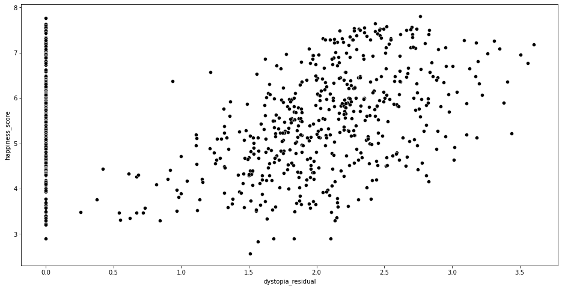

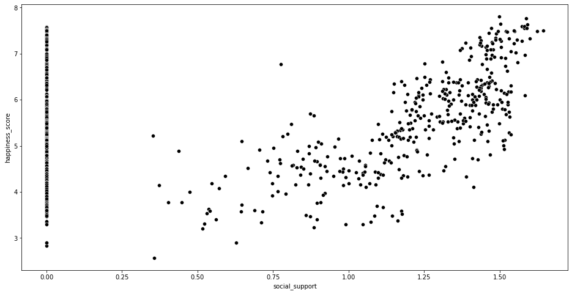

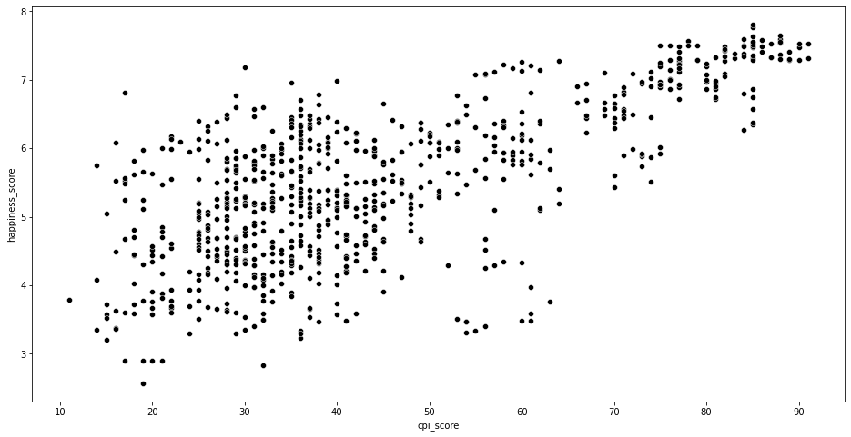

```python
for col in numeric_cols:
    plt.figure(figsize=(16,8))
    sns.scatterplot(x=happiness[col], y=happiness['happiness_score'], color ='black')
```

```python
happiness.continent.value_counts()
```

```
Europe           228
Asia             222
Africa           192
South America    120
North America     18
Australia         12
Name: continent, dtype: int64
```

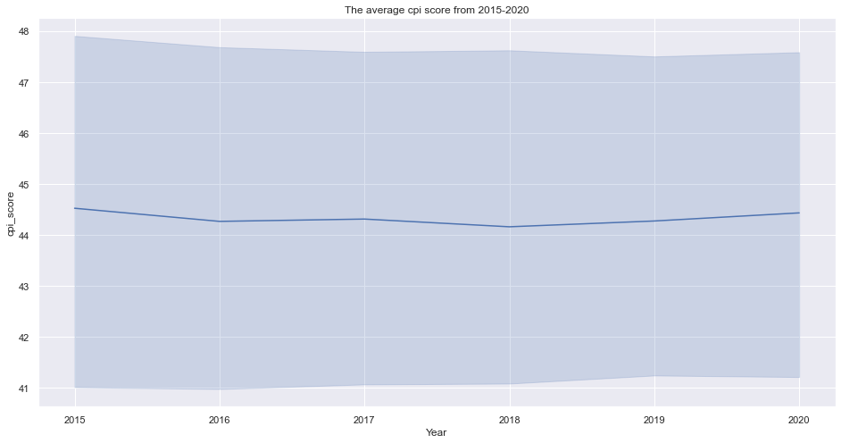

```python
plt.figure(figsize=(16,8))
plt.title("The average cpi score from 2015-2020")
sns.lineplot(data= happiness, x="Year",y= "cpi_score")
```

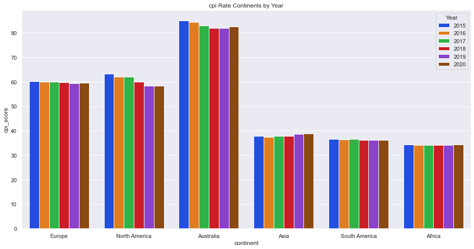

```python
plt.figure(figsize=(16,8))
plt.title('cpi Rate Continents by Year')
sns.barplot(data = happiness, x='continent', y='cpi_score',hue='Year',palette='bright', ci=None)
```

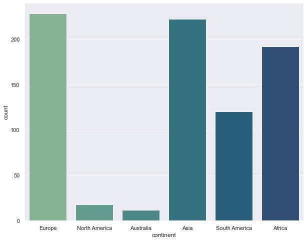

```python
f, ax = plt.subplots(figsize=(10, 8))
sns.countplot(data=happiness, x="continent",palette="crest", ax = ax)
plt.show()
```

```python
import plotly.express as px
fig = px.scatter(happiness, x="happiness_score", y="cpi_score", color = 'gdp_per_capita')
fig.update_layout(title_text='GDP and Corruption Perception Index by Happiness')
fig.show()
```

[interactive chart not shown]

# Correlation exploration

in this section, I will run the different correlation methods of pearson, kendall, and spearman. I am using all of them to show that the correlations vary between the different formulas for sorelation but they all so similar levels of correlation whether that is negative or positive for the variables. for instance, the correlation between family and social support are very highly and negatively correlated, the value for pearson being -0.87, kendall being -0.67 and spearman being -0.86. I also printed out the list of correlations relatign to cpi scores after each matrix. The correlation type I will be using later is pearson and my reasoning for that is given in the data and project overview section of my report.

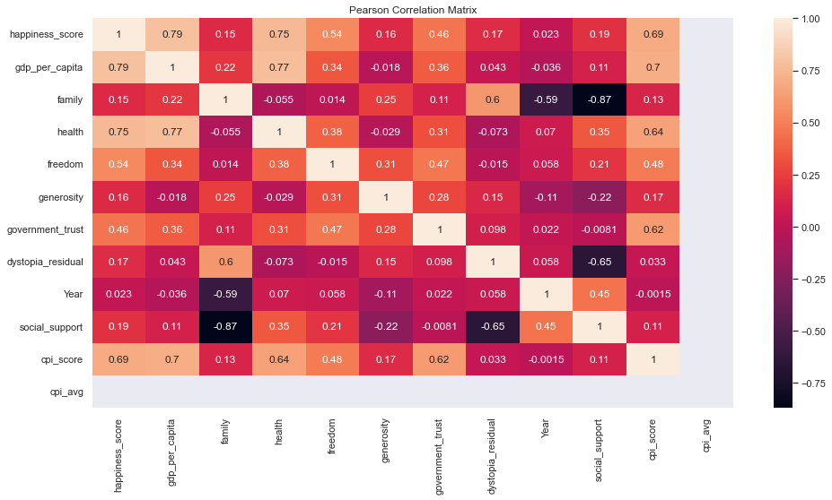

```python
plt.figure(figsize=(16,8))
pearson_matrix = happiness.corr(method = 'pearson')
sb.heatmap(pearson_matrix, annot=True)
plt.title("Pearson Correlation Matrix")
plt.show()
```

```python
pearson_matrix['cpi_score'].sort_values(ascending=False)
```

```
cpi_score            1.000000
gdp_per_capita       0.704483
happiness_score      0.693001
health               0.644478
government_trust     0.620089
freedom              0.482923
generosity           0.165972
family               0.132031
social_support       0.109077
dystopia_residual    0.032630
Year                -0.001460
Name: cpi_score, dtype: float64
```

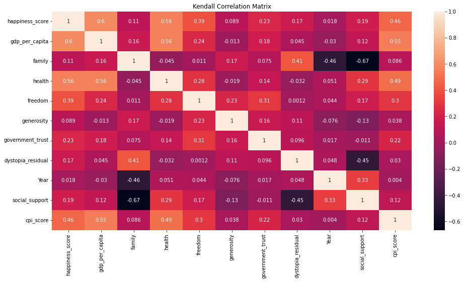

```python
plt.figure(figsize=(16,8))
kendall_matrix = happiness.corr(method = 'kendall')
sb.heatmap(kendall_matrix, annot=True)
plt.title("Kendall Correlation Matrix")
plt.show()
```

```python
kendall_matrix['cpi_score'].sort_values(ascending=False)
```

```
cpi_score            1.000000
gdp_per_capita       0.549202
health               0.492917
happiness_score      0.460575
freedom              0.297507
government_trust     0.223993
social_support       0.116086
family               0.085709
generosity           0.037803
dystopia_residual    0.030019
Year                 0.004040
Name: cpi_score, dtype: float64
```

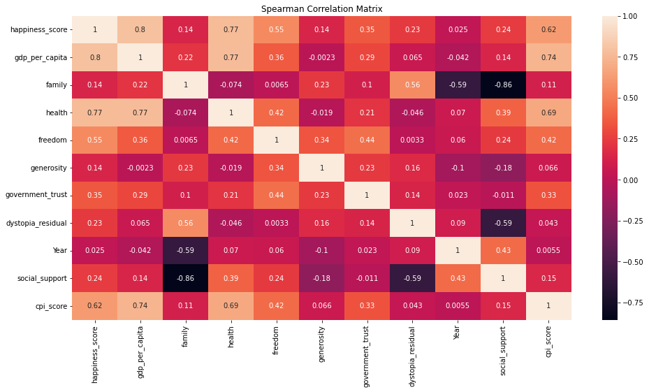

```python
plt.figure(figsize=(16,8))
spearman_matrix = happiness.corr(method = 'spearman')
sb.heatmap(spearman_matrix, annot=True)
plt.title("Spearman Correlation Matrix")
plt.show()
```

```python
spearman_matrix['cpi_score'].sort_values(ascending=False)
```

```
cpi_score            1.000000
gdp_per_capita       0.735174
health               0.685520
happiness_score      0.622027
freedom              0.422193
government_trust     0.333023
social_support       0.147637
family               0.113448
generosity           0.065831
dystopia_residual    0.042921
Year                 0.005542
Name: cpi_score, dtype: float64
```

# More Visualizations:

relating to cpi score and happiness sub scores I created linear model plots using the python package seaborn in order to visualize the relationship between all of them. from this we can see that although they all have a potitive relationship, the gdp and happiness scores seem the most correlated.

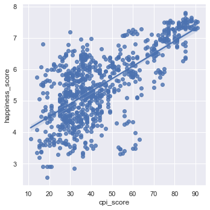

```python
plt.figure(figsize = (16,8))
sns.lmplot(x = 'cpi_score', y = 'happiness_score', data = happiness)
```

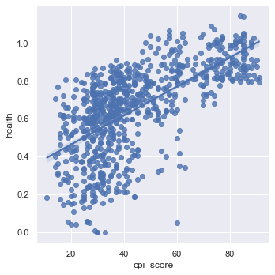

```python
plt.figure(figsize = (16,8))
sns.lmplot(x = 'cpi_score', y = 'health', data = happiness)
```

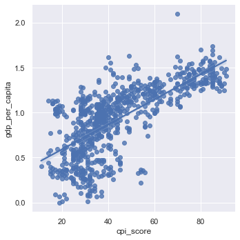

```python
plt.figure(figsize = (16,8))
sns.lmplot(x = 'cpi_score', y = 'gdp_per_capita', data = happiness)
```

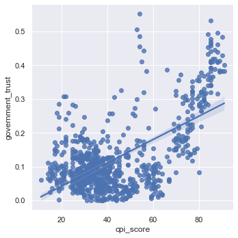

```python
plt.figure(figsize = (16,8))
sns.lmplot(x = 'cpi_score', y = 'government_trust', data = happiness)
```

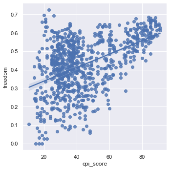

```python
plt.figure(figsize = (16,8))
sns.lmplot(x = 'cpi_score', y = 'freedom', data = happiness)
```

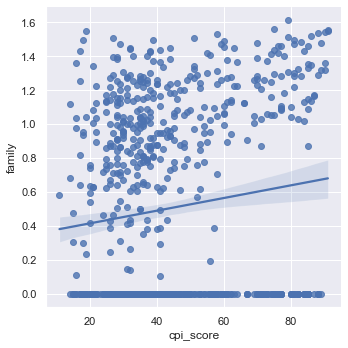

```python
plt.figure(figsize = (16,8))
sns.lmplot(x = 'cpi_score', y = 'family', data = happiness)
```

```python
plt.figure(figsize = (16,8))
sns.lmplot(x = 'cpi_score', y = 'happiness_score', data = happiness)
```

[output not shown]

# ANOVA REGRESSION

Instead of doing a linear regression like I did in the first project, I decided to do an anova regression insead. these are commonly used within social science fields and I learned them in both my poilitical statistics course and we briefly went over them in my psychology class that is dedicated to statistics and coding in R. Anova regressions calculate the varience within the data and regressions give the values. the steps include, creating an ols regression, then taking the anova model and creating a model from it. I printed out the values and you can see that there is a significant relationship between the happiness and cpi score because the p value is 0 which is less than .05, and same with the gdp relationship.

```python
cpi_model = smf.ols(formula='cpi_score ~ happiness_score', data=happiness).fit()
cpi_model.summary()
```

OLS Regression Results

| Dep. Variable: | cpi_score | R-squared: | 0.480 |
| --- | --- | --- | --- |
| Model: | OLS | Adj. R-squared: | 0.480 |
| Method: | Least Squares | F-statistic: | 730.0 |
| Date: | Wed, 07 Dec 2022 | Prob (F-statistic): | 2.24e-114 |
| Time: | 22:56:05 | Log-Likelihood: | -3217.1 |
| No. Observations: | 792 | AIC: | 6438. |
| Df Residuals: | 790 | BIC: | 6448. |
| Df Model: | 1 |  |  |
| Covariance Type: | nonrobust |  |  |

|  | coef | std err | t | P>\|t\| | [0.025 | 0.975] |
| --- | --- | --- | --- | --- | --- | --- |
| Intercept | -21.4643 | 2.486 | -8.634 | 0.000 | -26.344 | -16.585 |
| happiness_score | 12.0204 | 0.445 | 27.018 | 0.000 | 11.147 | 12.894 |

| Omnibus: | 1.850 | Durbin-Watson: | 1.655 |
| --- | --- | --- | --- |
| Prob(Omnibus): | 0.397 | Jarque-Bera (JB): | 1.704 |
| Skew: | 0.010 | Prob(JB): | 0.427 |
| Kurtosis: | 2.774 | Cond. No. | 28.6 |

Notes:  
[1] Standard Errors assume that the covariance matrix of the errors is correctly specified.

```python
anova_cpi = sm.stats.anova_lm(cpi_model, typ=2)
anova_cpi
```

|  | sum_sq | df | F | PR(>F) |
| --- | --- | --- | --- | --- |
| happiness_score | 144579.676289 | 1.0 | 729.964132 | 2.239729e-114 |
| Residual | 156470.625478 | 790.0 | NaN | NaN |

```python
cpi_gdp_model = smf.ols(formula='cpi_score ~ gdp', data=happiness).fit()
cpi_gdp_model.summary()
```

OLS Regression Results

[output not shown]

[output not shown]

[output not shown]

Notes:  
[1] Standard Errors assume that the covariance matrix of the errors is correctly specified.

```python
anova_cpi_gdp = sm.stats.anova_lm(cpi_gdp_model, typ=2)
anova_cpi
```

[output not shown]

|  | sum_sq | df | F | PR(>F) |
| --- | --- | --- | --- | --- |
| happiness_score | 144579.676289 | 1.0 | 729.964132 | 2.239729e-114 |
| Residual | 156470.625478 | 790.0 | NaN | NaN |

# Conclusions

We can conclude from my exploratory data analysis that cpi score is correlated to both the gdp and happiness scores.

# citations:

https://www.transparency.org/en/cpi/2021 https://www.kaggle.com/code/eliasturk/visualization-and-regression-predictive-models#Linear-Regression-Algorithm https://towardsdatascience.com/analysis-of-variance-anova-8dc889d2fc3a https://plotly.com/python-api-reference/generated/plotly.express.scatter.html